# XRayTest

**In notebook settings do not select Omit code cell output when saving this notebook**

In this assignement you will build a decision tree and a random forest classifier to classify x ray images of potential covid 19 patients. For Test and training data refer to canvas.

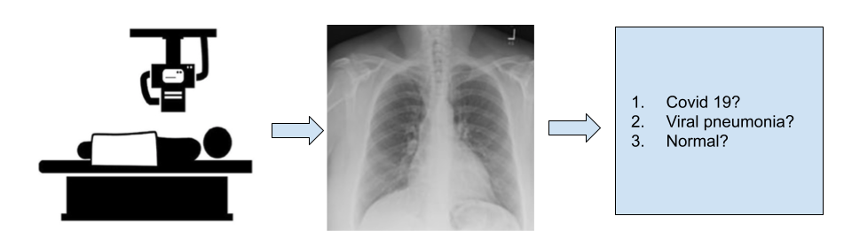

Step 01 : import any libraries you want here. Some common ones are already imported.

```python
from sklearn.tree import DecisionTreeClassifier
from sklearn.ensemble import RandomForestClassifier
from sklearn.metrics import ConfusionMatrixDisplay
from sklearn.model_selection import GridSearchCV
from sklearn.metrics import accuracy_score, confusion_matrix, classification_report
from sklearn.model_selection import train_test_split
import matplotlib.pyplot as plt
from google.colab import drive
import os
import numpy as np
from PIL import Image
import matplotlib.image as mpimg
from skimage.io import imread
from skimage.transform import resize
from sklearn.preprocessing import StandardScaler

# add additional libraries used
```

Step 02 : upload the data from canvas to the top level folder of your google drive. write code to load the data from the google drive.

```python
drive.mount('/content/drive')
```

```python
root_path = '/content/drive/MyDrive/Covid19-dataset' # do not change the root path.

## TODO: load data and generate corresponding labels
def load_data(root_path):
    labels = []
    file_paths = []
    for subset in ['train', 'test']:
        subset_path = os.path.join(root_path, subset)
        for label in os.listdir(subset_path):
            label_path = os.path.join(subset_path, label)
            if os.path.isdir(label_path):
                for file_name in os.listdir(label_path):
                    file_path = os.path.join(label_path, file_name)
                    labels.append(label)
                    file_paths.append(file_path)
    return file_paths, labels


file_paths, labels = load_data(root_path)

for i in range(317):
    print("File path:", file_paths[i])
    print("Label:", labels[i])
    print()
```

[output not shown]

[output cut: 895 more lines]

[output not shown]

Step 03: visualize one x-ray image from each type : "covid 19", "viral pneumonia", "normal"

```
Covid
Normal
Viral Pneumonia
```

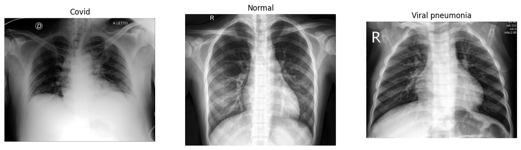

```python
## TODO

# Visualize one image from each class
def find_image_path(root_path, label):
    for subset in ['train', 'test']:
        label_path = os.path.join(root_path, subset, label)
        if os.path.exists(label_path):
            file_names = os.listdir(label_path)
            image_files = [f for f in file_names if f.endswith('.jpeg') or f.endswith('.png')]
            if image_files:
                return os.path.join(label_path, image_files[0])
    return None

labels2 = ["Covid", "Normal", "Viral Pneumonia"]

plt.figure(figsize=(15, 5))
for i, label in enumerate(labels2, 1):
    plt.subplot(1, 3, i)
    image_path = find_image_path(root_path, label)
    print(label)
    if image_path:
        image = mpimg.imread(image_path)
        plt.imshow(image, cmap='gray')
        plt.title(label.capitalize())
        plt.axis('off')
    else:
        print(f"No image found for {label}")
plt.show()
```

Step 04 : Find the best decision tree to classifiy the x-ray images. Remember to set the random seed for reproducibiity. Find the best critirion and the max_depth using 5 fold cross validation.

```python
from skimage.io import imread
from skimage.transform import resize
from sklearn.preprocessing import StandardScaler
np.random.seed(42)
print("Length of file_paths:", len(file_paths))
print("Length of labels:", len(labels))

X_train, X_test, y_train, y_test = train_test_split(file_paths, labels, test_size=0.2, random_state=42)
X_train_images = []
X_test_images = []
y_train = np.array(y_train)
y_test = np.array(y_test)

for file_path in X_train:
    image = imread(file_path, as_gray=True)
    image_resized = resize(image, (64, 64))
    X_train_images.append(image_resized.flatten())

X_train = np.array(X_train_images)

for file_path in X_test:
    image = imread(file_path, as_gray=True)
    image_resized = resize(image, (64, 64))
    X_test_images.append(image_resized.flatten())

X_test = np.array(X_test_images)

scaler = StandardScaler()
X_train_scaled = scaler.fit_transform(X_train)
X_test_scaled = scaler.transform(X_test)

tree_classifier = DecisionTreeClassifier(random_state=42)

param_grid = {
    'criterion': ['gini', 'entropy'],
    'max_depth': [3, 5, 7, 10, None]
}

grid_search = GridSearchCV(tree_classifier, param_grid, cv=5, scoring='accuracy')
grid_search.fit(X_train_scaled, y_train)

best_params = grid_search.best_params_
print("Best Parameters:", best_params)

best_score = grid_search.best_score_
print("Best Mean Cross-validated Score:", best_score)

test_accuracy = grid_search.score(X_test_scaled, y_test)
print("Test Accuracy:", test_accuracy)
```

```
Length of file_paths: 317
Length of labels: 317
Best Parameters: {'criterion': 'gini', 'max_depth': 7}
Best Mean Cross-validated Score: 0.7510588235294118
Test Accuracy: 0.828125
```

Step 05 : Draw the confution matrix. Starter code is given below.

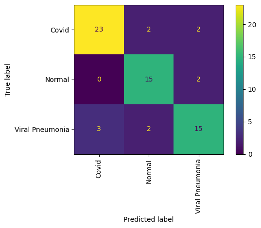

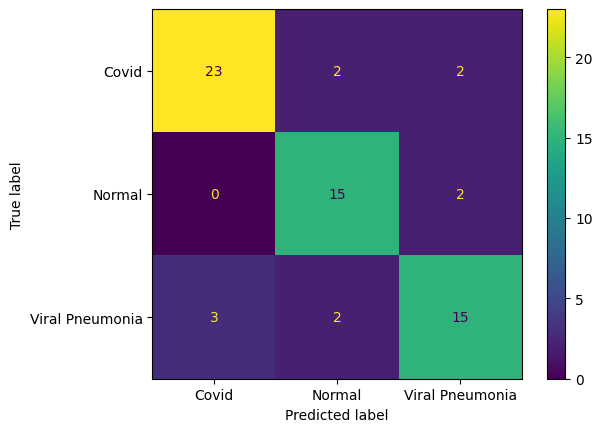

```python
unique_labels = np.unique(y_test)

target_names = [str(label) for label in unique_labels]

best_estimator = grid_search.best_estimator_

cm_display = ConfusionMatrixDisplay.from_estimator(best_estimator, X_test_scaled, y_test, display_labels=target_names, xticks_rotation="vertical")

plt.tight_layout()
cm_display.plot()
plt.show()
```

Step 06 : Find a random forest classifier to classifiy the x-ray images. Remember to set the random seed for reproducibiity. Find the best critirion and the number of trees needed using 5 fold cross validation.

```python
## TODO
np.random.seed(42)

rf_classifier = RandomForestClassifier(random_state=42)

param_grid = {
    'n_estimators': [50, 100, 150],
    'criterion': ['gini', 'entropy']
}

grid_search = GridSearchCV(rf_classifier, param_grid, cv=5, scoring='accuracy')
grid_search.fit(X_train_scaled, y_train)

best_params = grid_search.best_params_
print("Best Parameters:", best_params)

best_score = grid_search.best_score_
print("Best Mean Cross-validated Score:", best_score)

test_accuracy = grid_search.score(X_test_scaled, y_test)
print("Test Accuracy:", test_accuracy)
```

```
Best Parameters: {'criterion': 'entropy', 'n_estimators': 100}
Best Mean Cross-validated Score: 0.9129411764705881
Test Accuracy: 0.90625
```

Step 07 : Draw the confution matrix. Starter code is given below.

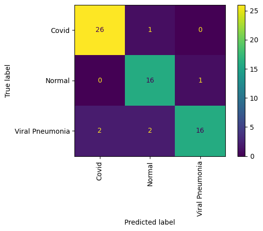

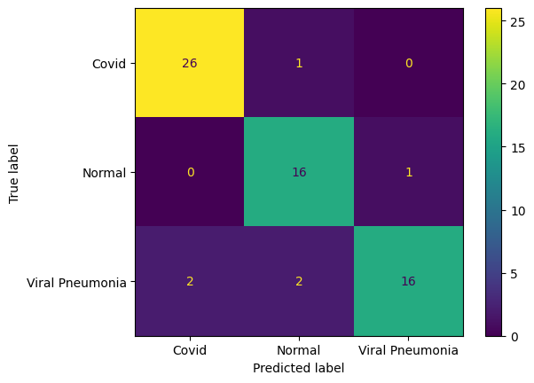

```python
best_estimator = grid_search.best_estimator_

cm_display = ConfusionMatrixDisplay.from_estimator(best_estimator, X_test_scaled, y_test, display_labels=target_names, xticks_rotation="vertical")

plt.tight_layout()
cm_display.plot()
plt.show()
```